# Final_Project

Adam Brandt, Allan Juarez, John King, Lisa McDaniel, Colin Willenborg (Project Coordinator)

11/10/2020

**Introduction**

The 5 Year program is prepared by the Iowa Department of Transportation (Iowa DOT) and identifies transportation projects planned for construction on a annual basis for a period of five years, in this case 2021-2025. The program includes projects for aviation, transit, railroad, safety, trails and highway. Project location, county, work type, route, length and annual construction costs are included in the program for each project listed. The document is updated annually by removing completed projects, introducing new projects, revising project schedules and costs and rescheduling projects as needed. It is approved by the Iowa DOT commission and provides transparency to the public by being available on the Iowa DOT’s website.

Information in the 5 Year Program can assist the Iowa DOT, local public agencies and the federal government in developing a budget, identifying needs, project status, documentation requirements and staffing resources. The document also makes it easier for organizations to compare estimated project costs with actual project costs and track project costs/status over the years, across the state/county and by project. There is a lot of information in the 5 Year Program, so we focused our analysis on the highway program, which begins on page 50.

**Dataset Overview**

The 5 Year Program can be found on the Iowa DOT’s website at:

https://iowadot.gov/program_management/FINAL_2021-2025_5YrProg.pdf

The 5 Year Program was originally created as a pdf and exported to an excel spreadsheet. The conversion was a bit messy so quality assurance (QA) was done to ensure that project costs were correct and in the correct year. Several columns were added to the dataset including Iowa DOT District, county latitude and longitude and projects rescheduled in case the Highway Trust Funds becomes insolvent. We also *filled down* the project location and miles for each work type and renamed several columns. As each of us explored the data, we continued to make various changes/revisions specific to our individual analysis.

```
## # A tibble: 6 x 20
## # Groups:   County, District, Route, Location [6]
##   State County `Latitude\r\n(T~ `Latitude\r\n(D~ Latitude `Longitude\r\n(~
##   <chr> <chr>             <dbl>            <dbl> <chr>               <dbl>
## 1 Iowa  Adair            412043             41.3 41° 20'~          -942818
## 2 Iowa  Adair                NA             NA   <NA>                   NA
## 3 Iowa  Adair                NA             NA   <NA>                   NA
## 4 Iowa  Adair                NA             NA   <NA>                   NA
## 5 Iowa  Adair                NA             NA   <NA>                   NA
## 6 Iowa  Adair                NA             NA   <NA>                   NA
## # ... with 14 more variables: `Longitude\r\n(Decimal)` <dbl>, Longitude <chr>,
## #   District <dbl>, Route <dbl>, Location <chr>, `State Share` <chr>,
## #   `Reschedule if the HTF Becomes Insolvent` <chr>, Miles <dbl>, Work <chr>,
## #   `2021` <dbl>, `2022` <dbl>, `2023` <dbl>, `2024` <dbl>, `2025` <dbl>
```

## Allan Juarez

- Type, number, route, and location by County and estimated costs of projects planned between 2021 – 2025. Where is the money going and how much?

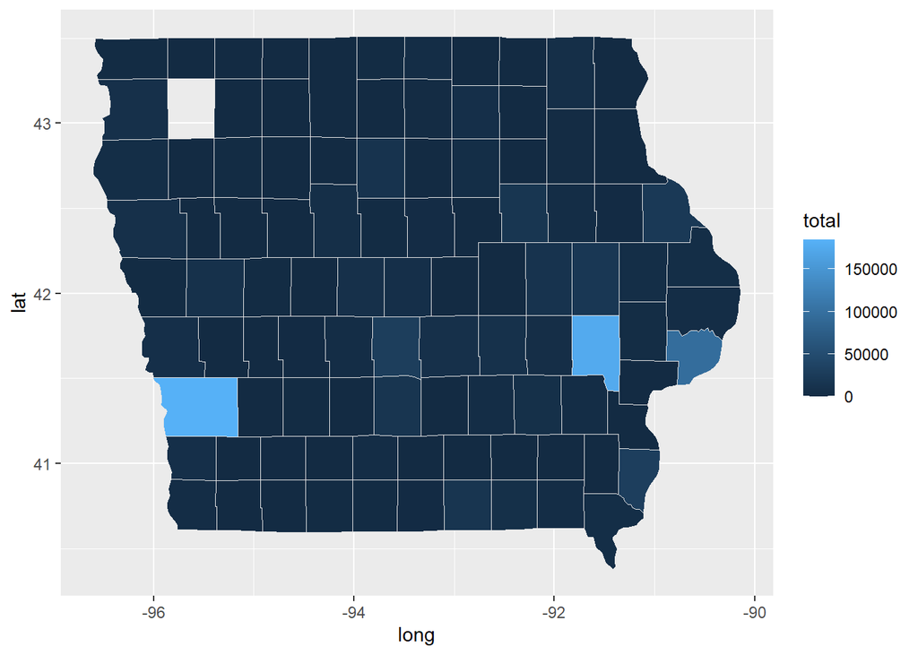

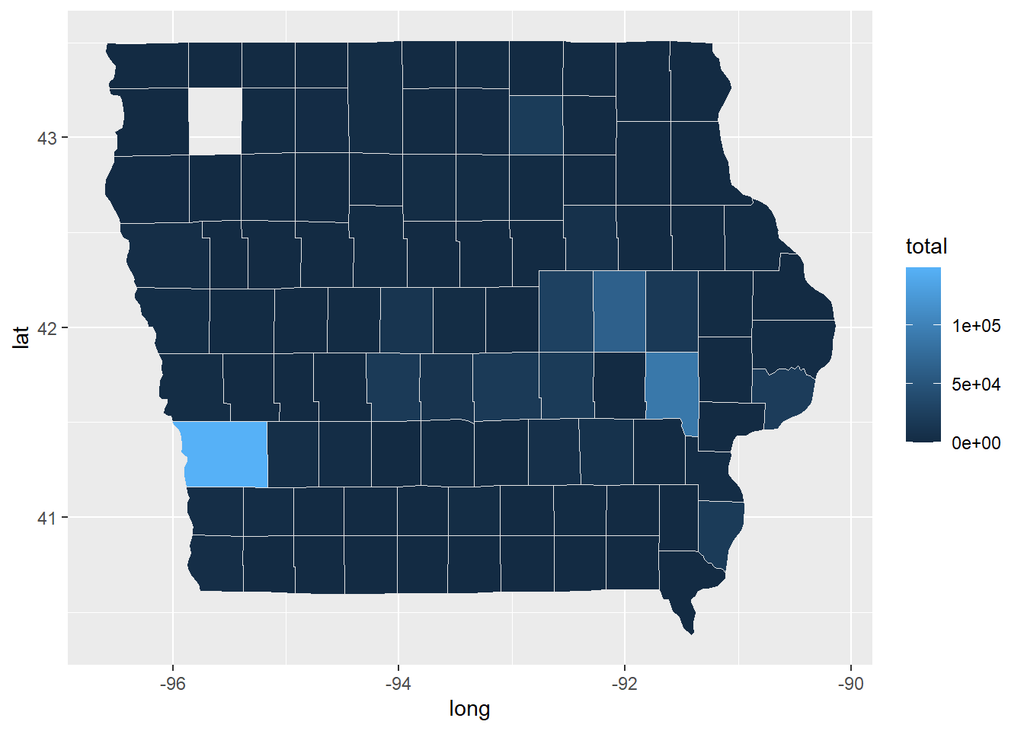

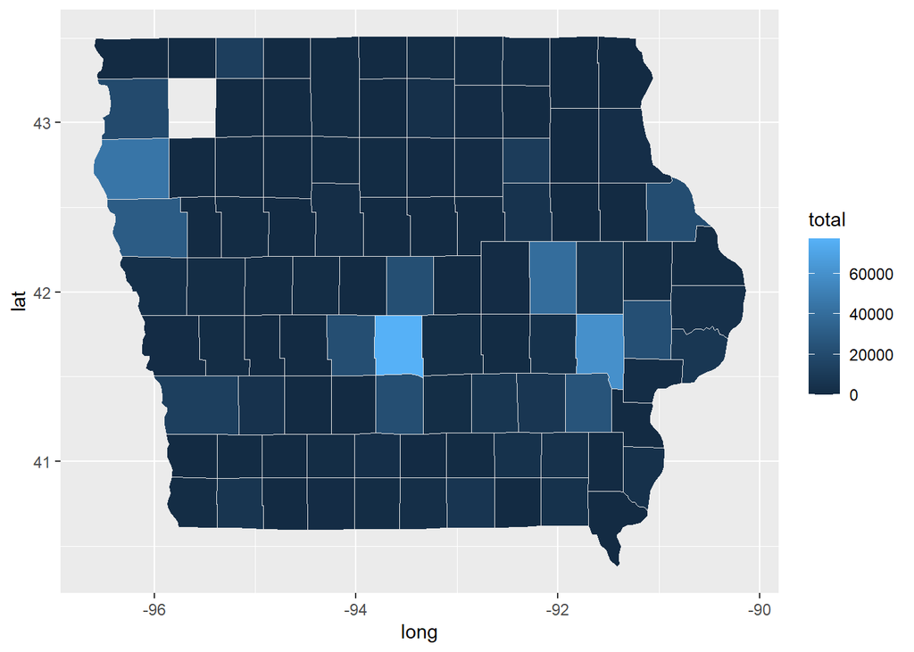

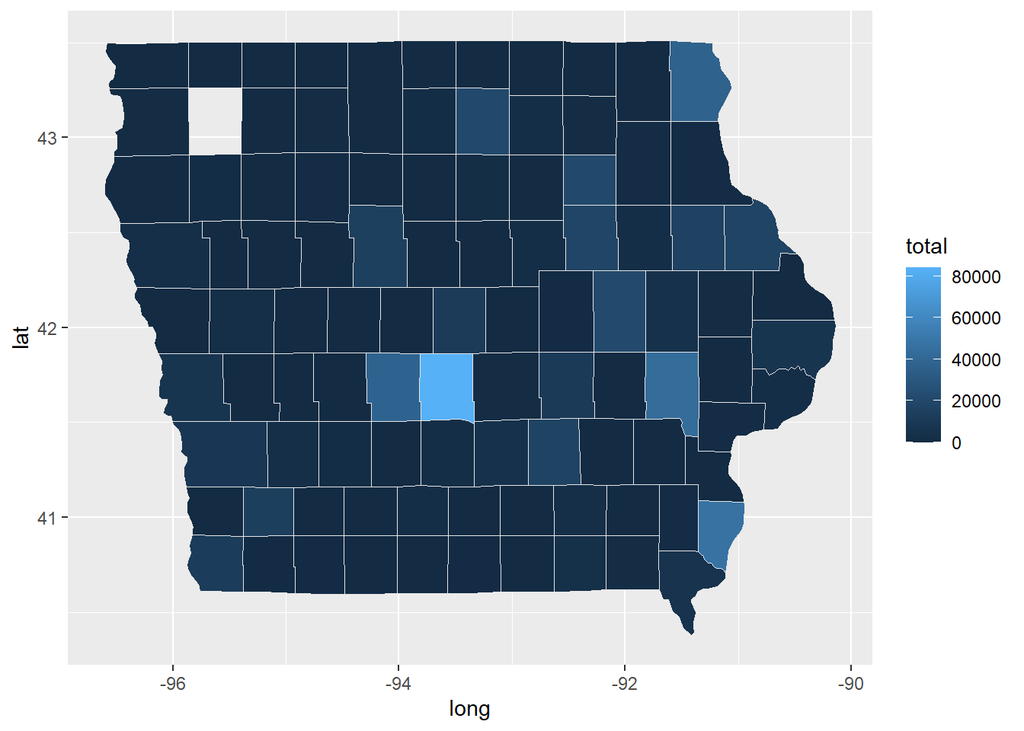

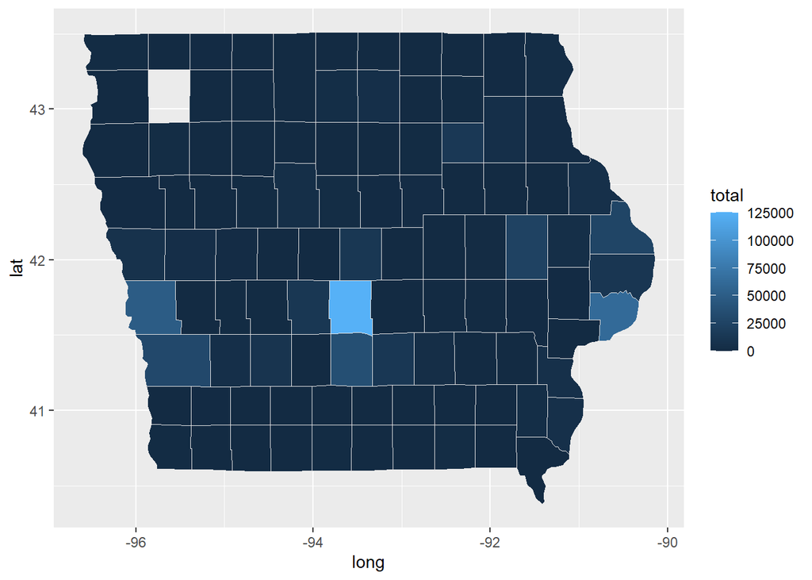

```
## # A tibble: 10 x 2
##    Work                      n
##    <chr>                 <int>
##  1 BRIDGE DECK OVERLAY     220
##  2 BRIDGE REPLACEMENT      139
##  3 RIGHT OF WAY            110
##  4 PAVEMENT REHAB           74
##  5 GRADE AND PAVE           70
##  6 TRAFFIC SIGNS            57
##  7 BRIDGE REHABILITATION    36
##  8 EROSION CONTROL          33
##  9 BRIDGE CLEANING          25
## 10 LIGHTING                 21
```

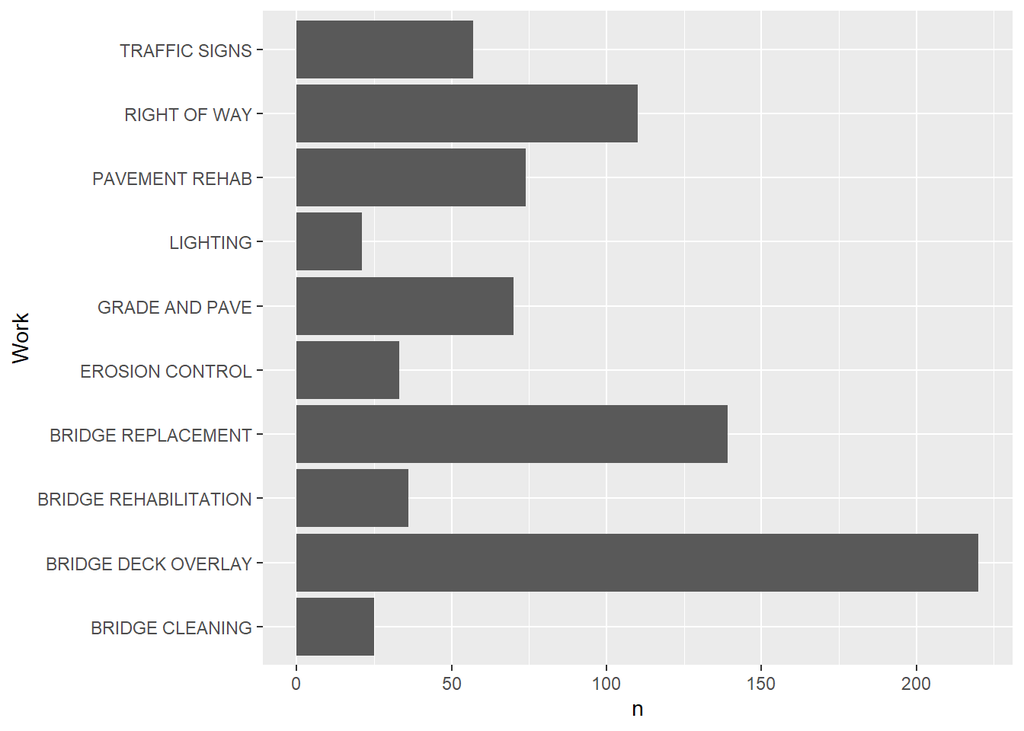

```
## # A tibble: 99 x 2
##    County            n
##    <chr>         <int>
##  1 Polk             67
##  2 Pottawattamie    55
##  3 Linn             34
##  4 Dubuque          33
##  5 Scott            33
##  6 Johnson          32
##  7 Benton           25
##  8 Des Moines       25
##  9 Woodbury         24
## 10 Cerro Gordo      23
## # ... with 89 more rows
```

These charts show the different projects and how much money is going to go into each county for the next five years. Over the next five years Iowa will be working on many bridge projects. There are over 400 bridge projects that are gonna be worked on. With bridge deck overlay being the most worked on. If bridges are not being worked on then there is right of way and pavement projects that are coming up to work on Iowa’s infrastructure.

From the dataset we can see which counties has the most projects coming up. To no surprise Polk county has the most projects projected to happen with 67 total projects to work on. This makes sense since Polk county holds des moines and a bunch of suburbs that has a lot of people living there. With all these factors there is going to be a need for a lot of projects for the roads their. THe county with the second most projects is Pottawattamie at 55. Im not really familiar with that area, but it has 55 upcoming projects which is not far off from Polk county.

## John King

- What work types are associated with interchanges? Costs? What routes are interchanges being proposed on?

Work Types Associated with Interchanges

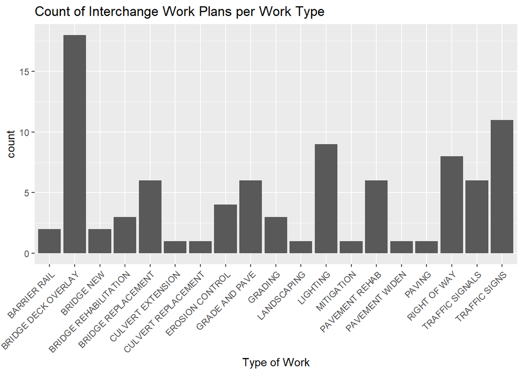

Bridge Deck Overlays seem to be the most common type of work on the interchanges. It seems that a great number of planned projects are related to maintenance or additions for the sake of drivers (traffic signs, traffic signals, lighting).

Costs of projects Involving interchanges

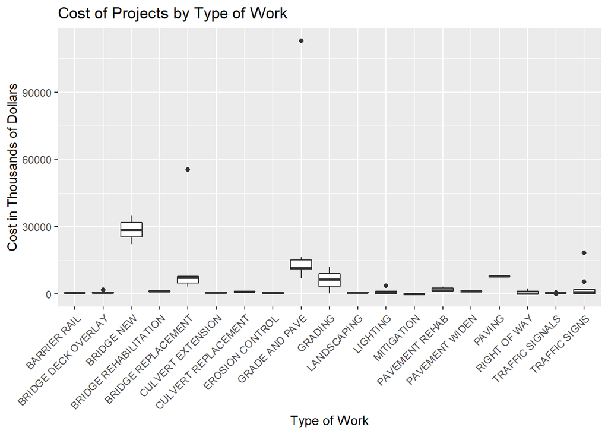

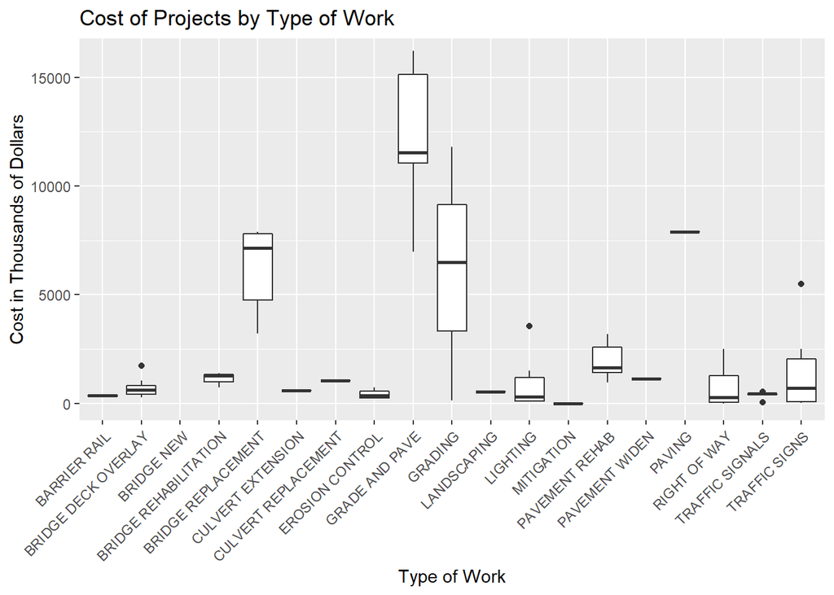

The first chart shows that the grade and pave and new bridge projects are the most expensive. Now we zoom in the plot ignoring the outliers to better see the other categories. From this chart we can see that most of the projects are relatively cheap in comparison (under 15 million dollars), with only bridge replacement, grading, and paving projects frequently approaching the this upper bound.

Counties with Proposed Interchanges

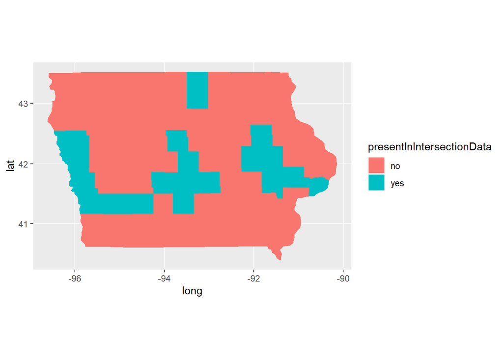

[figure not shown]

Retreived from http://ontheworldmap.com/usa/state/iowa/iowa-road-map.html

The upper of the two charts is a map that highlights counties that have planned interchange projects within their borders. Meanwhile, the lower of the two charts is a state map containing the major highways of Iowa. In it, the blue highways are the interstate highways, and the highlighted counties match up with the counties along the route of the interstates. This shows us that most interchanges are on the interstates, meaning routes 29, 35, 80, and 380.

Routes with proposed interchanges

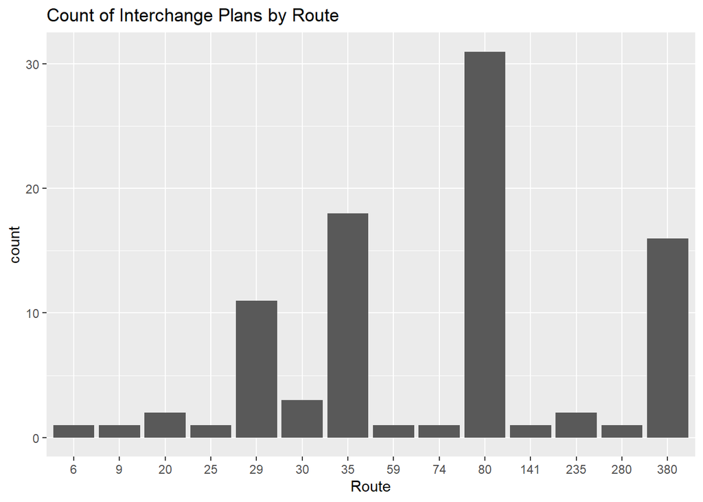

The previous assumption can be shown in this chart, which shows the routes interchanges are planned for. 29, 35, 80, and 380 are the routes with the most interchanges, and the other routes are likely the routes 29, 35, 80, or 380 are interchanging with.

## Adam Brandt

- Projects < $50 million, projects > $50 million & < $100 million, major projects > $100. What is the most expensive project in each District? The least expensive?

```
## # A tibble: 6 x 5
## # Groups:   County, District, Route [5]
##   County        District Route Location                                     cost
##   <chr>            <dbl> <dbl> <chr>                                       <dbl>
## 1 Pottawattamie        4    80 I-29/80/480 INTERSTATES IN COUNCIL BLUFFS~ 319603
## 2 Johnson              6    80 I-380/US 218 INTERCHANGE NEAR IOWA CITY    216474
## 3 Polk                 1    35 NE 36TH ST IN ANKENY TO N OF IA 210        129471
## 4 Johnson              6    80 1.5 MI E OF IA 1 TO 0.5 MI E OF CO RD X30  124569
## 5 Benton               6    30 11TH AVE DR TO W JCT US 218                 99938
## 6 Scott                6    74 IN BETTENDORF AND DAVENPORT (CENTRAL SECT~  85268
```

```
## # A tibble: 6 x 5
## # Groups:   County, District, Route [6]
##   County   District Route Location                                          cost
##   <chr>       <dbl> <dbl> <chr>                                            <dbl>
## 1 Emmet           3    NA 0.35 MI S OF CO RD D53 (SB)                          0
## 2 Osceola         3    NA ABANDONED RR 0.9 MI S OF CO RD B40 (REMOVE BRID~     0
## 3 Boone           1    30 1.8 MI W OF DES MOINES RIVER TO W OF SNEDDEN DR      2
## 4 Warren          5    69 120TH AVE 0.75 MI N OF CO RD G64                    10
## 5 Franklin        2    35 DRAINAGE DITCH #29 1.3 MI N OF CO RD C70 (SB)       18
## 6 Davis           5    63 N FABIUS CREEK 2.6 MI N OF MISSOURI STATE LINE      20
```

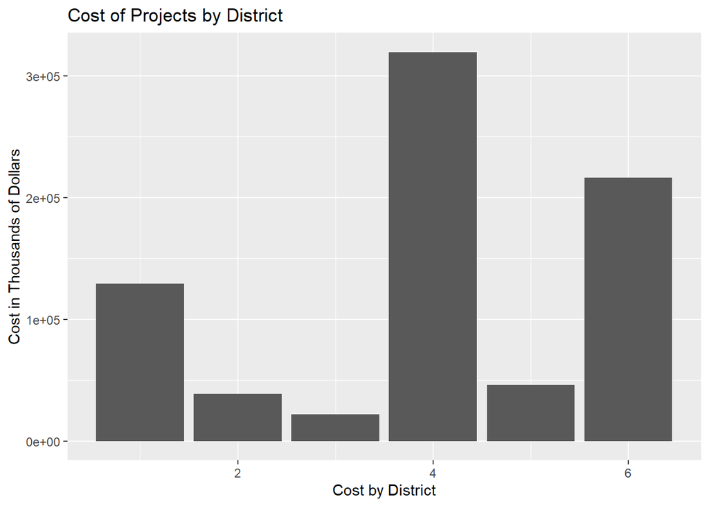

```
## # A tibble: 6 x 5
## # Groups:   District [6]
##   County       District Route Location                                      cost
##   <chr>           <dbl> <dbl> <chr>                                        <dbl>
## 1 Polk                1    35 NE 36TH ST IN ANKENY TO N OF IA 210         129471
## 2 Bremer              2   218 CEDAR RIVER IN JANESVILLE TO IA 116 IN WAV~  38671
## 3 Plymouth            3    75 N OF MAPLE ST IN HINTON TO S OF 2ND ST IN ~  22043
## 4 Pottawattam~        4    80 I-29/80/480 INTERSTATES IN COUNCIL BLUFFS ~ 319603
## 5 Des Moines          5    61 S OF 210TH ST TO N OF MEDIAPOLIS             46155
## 6 Johnson             6    80 I-380/US 218 INTERCHANGE NEAR IOWA CITY     216474
```

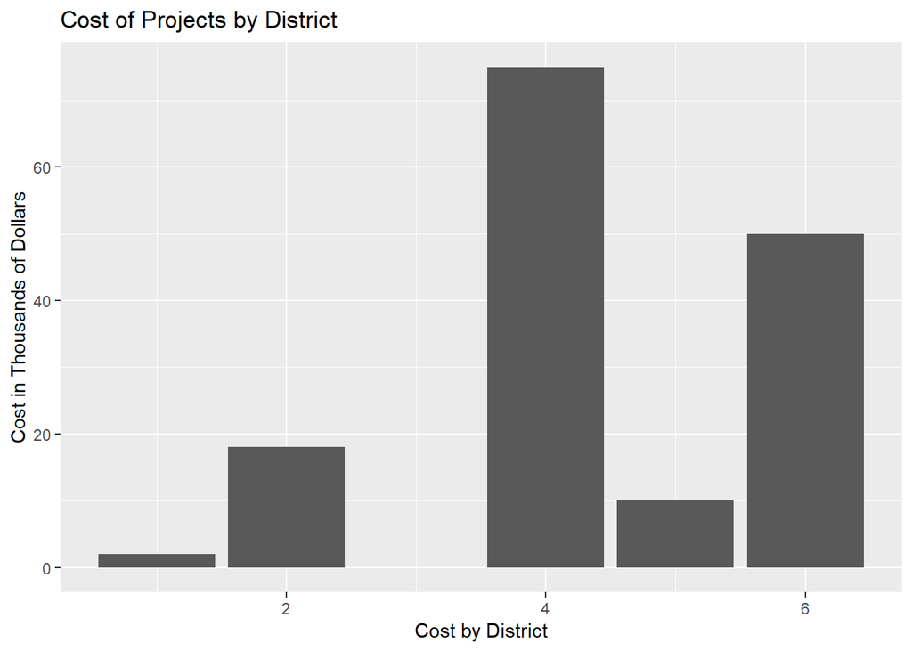

```
## # A tibble: 6 x 5
## # Groups:   District [6]
##   County   District Route Location                                         cost
##   <chr>       <dbl> <dbl> <chr>                                           <dbl>
## 1 Boone           1    30 1.8 MI W OF DES MOINES RIVER TO W OF SNEDDEN DR     2
## 2 Franklin        2    35 DRAINAGE DITCH #29 1.3 MI N OF CO RD C70 (SB)      18
## 3 Emmet           3    NA 0.35 MI S OF CO RD D53 (SB)                         0
## 4 Harrison        4    29 LITTLE SIOUX RIVER N OF CO RD F20 INTERCHANGE      75
## 5 Warren          5    69 120TH AVE 0.75 MI N OF CO RD G64                   10
## 6 Dubuque         6    20 0.6 MI E OF THE NORTHWEST ARTERIAL IN DUBUQUE      50
```

```
## $`(0,5e+04]`
## # A tibble: 629 x 5
## # Groups:   County, District, Route [267]
##    County    District Route Location                                        cost
##    <chr>        <dbl> <dbl> <chr>                                          <dbl>
##  1 Adair            4    25 GREENFIELD TO I-80                              1350
##  2 Adair            4    25 I-80 INTERCHANGE                                 333
##  3 Adair            4    80 CASS CO TO IA 25 (WB)                           8977
##  4 Adair            4    80 IA 25 TO MADISON CO (EB)                        2866
##  5 Adair            4    92 GRAND RIVER 1.0 MI W OF CO RD P28                490
##  6 Adair            4    92 W FORK NODAWAY RIVER 1.6 MI E OF CO RD N51      1800
##  7 Adams            4   148 MIDDLE NODAWAY RIVER 1.8 MI S OF S JCT CO RD ~   712
##  8 Allamakee        2     9 MISSISSIPPI RIVER BRIDGE IN LANSING            37124
##  9 Allamakee        2     9 MISSISSIPPI RIVER IN LANSING                     100
## 10 Allamakee        2    76 MINERAL CREEK 1.6 MI S OF CO RD A26              200
## # ... with 619 more rows
##
## $`(5e+04,1e+05]`
## # A tibble: 6 x 5
## # Groups:   County, District, Route [6]
##   County   District Route Location                                       cost
##   <chr>       <dbl> <dbl> <chr>                                         <dbl>
## 1 Benton          6    30 11TH AVE DR TO W JCT US 218                   99938
## 2 Dallas          4    80 US 6/169 IN DE SOTO TO CO RD R16              52496
## 3 Harrison        4    30 MISSOURI VALLEY BYPASS                        51056
## 4 Polk            1    35 I-80/235 INTERCHANGE NE OF DES MOINES         61836
## 5 Scott           6    74 IN BETTENDORF AND DAVENPORT (CENTRAL SECTION) 85268
## 6 Scott           6    80 MISSISSIPPI RIVER IN LE CLAIRE                50625
##
## $`(1e+05,1e+06]`
## # A tibble: 4 x 5
## # Groups:   County, District, Route [3]
##   County        District Route Location                                     cost
##   <chr>            <dbl> <dbl> <chr>                                       <dbl>
## 1 Johnson              6    80 1.5 MI E OF IA 1 TO 0.5 MI E OF CO RD X30  124569
## 2 Johnson              6    80 I-380/US 218 INTERCHANGE NEAR IOWA CITY    216474
## 3 Polk                 1    35 NE 36TH ST IN ANKENY TO N OF IA 210        129471
## 4 Pottawattamie        4    80 I-29/80/480 INTERSTATES IN COUNCIL BLUFFS~ 319603
```

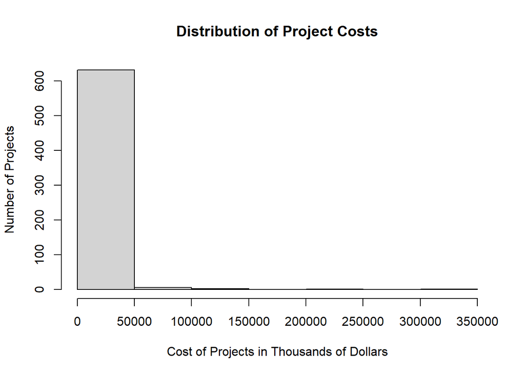

## Colin Willenborg(Project Coordinator)

An important part of any budget from year to year is comparing it and seeing where the money is going. In this five year plan the money can be analyzed in different ways. One of these ways is by looking at the DOT districts. There are 6 districts in Iowa. The graphs in this next section look at the districts and groups the counties by DOT district and adds up the total budget of all projects in those counties. So the question that I am trying to answer is what does the spending break down look like by DOT district and what is the spending breakdown by person per DOT district. I will get into these two questions below.

```
## # A tibble: 6 x 2
##   District  total
##      <dbl>  <dbl>
## 1        1  70519
## 2        2  54929
## 3        3  40056
## 4        4 210056
## 5        5  96191
## 6        6 351621
```

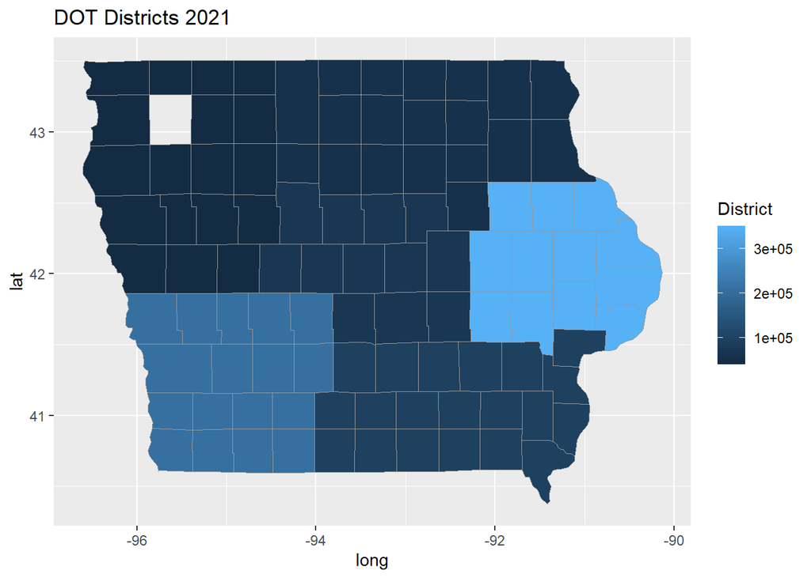

```
## # A tibble: 6 x 2
##   District  total
##      <dbl>  <dbl>
## 1        1  93786
## 2        2  39065
## 3        3  12707
## 4        4 189206
## 5        5  42751
## 6        6 197580
```

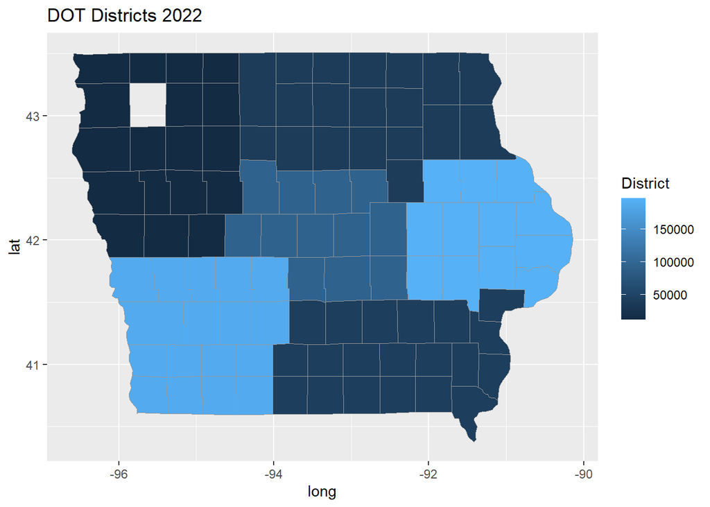

```
## # A tibble: 6 x 2
##   District  total
##      <dbl>  <dbl>
## 1        1 106149
## 2        2  29876
## 3        3 115060
## 4        4  52204
## 5        5  95969
## 6        6 169342
```

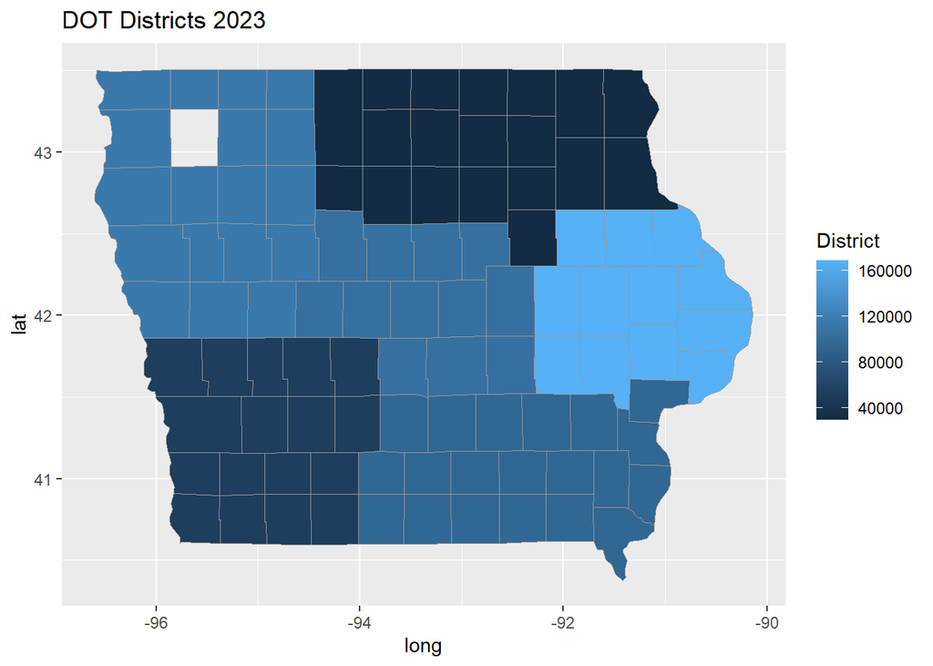

```
## # A tibble: 6 x 2
##   District  total
##      <dbl>  <dbl>
## 1        1 124234
## 2        2 106091
## 3        3  11674
## 4        4  85165
## 5        5  88383
## 6        6 115155
```

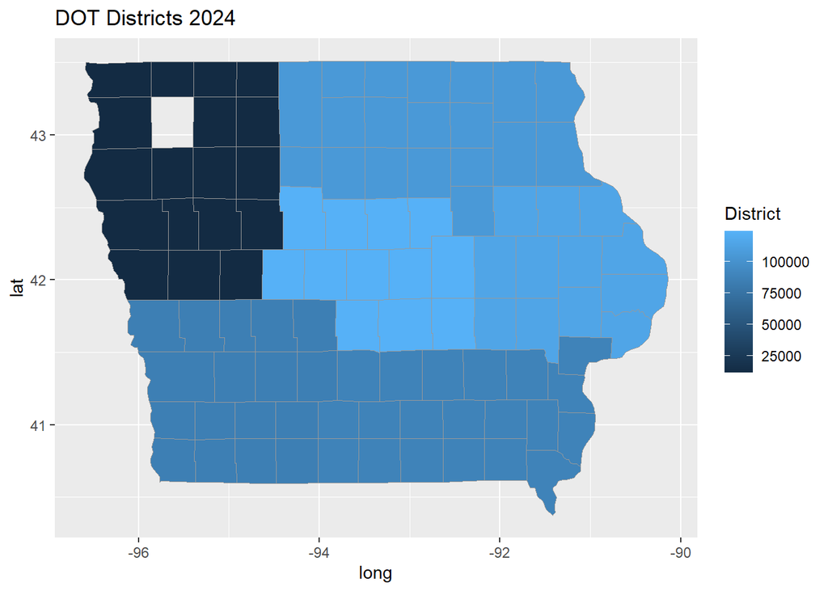

```
## # A tibble: 6 x 2
##   District  total
##      <dbl>  <dbl>
## 1        1 146151
## 2        2  32137
## 3        3  18143
## 4        4 109256
## 5        5  70198
## 6        6 136768
```

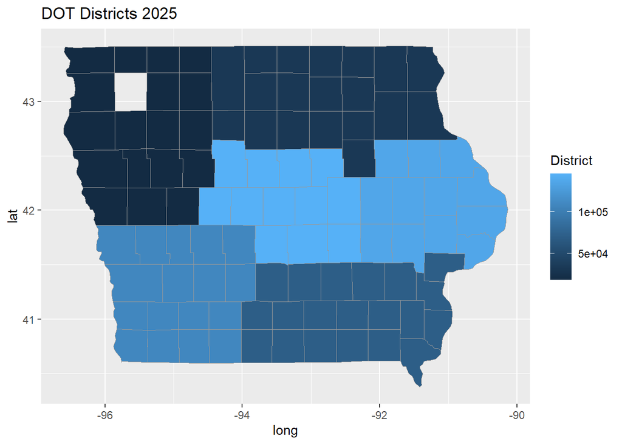

```
## # A tibble: 6 x 4
##   District  total total_pop spent_per_pop
##      <dbl>  <dbl>     <dbl>         <dbl>
## 1        1  70519    814067          86.6
## 2        2  54929    233065         236.
## 3        3  40056    326790         123.
## 4        4 210056    338624         620.
## 5        5  96191    361038         266.
## 6        6 351621    833291         422.
```

```
## # A tibble: 6 x 4
##   District  total total_pop spent_per_pop
##      <dbl>  <dbl>     <dbl>         <dbl>
## 1        1  93786    814067         115.
## 2        2  39065    233065         168.
## 3        3  12707    326790          38.9
## 4        4 189206    338624         559.
## 5        5  42751    361038         118.
## 6        6 197580    833291         237.
```

```
## # A tibble: 6 x 4
##   District  total total_pop spent_per_pop
##      <dbl>  <dbl>     <dbl>         <dbl>
## 1        1 106149    814067          130.
## 2        2  29876    233065          128.
## 3        3 115060    326790          352.
## 4        4  52204    338624          154.
## 5        5  95969    361038          266.
## 6        6 169342    833291          203.
```

```
## # A tibble: 6 x 4
##   District  total total_pop spent_per_pop
##      <dbl>  <dbl>     <dbl>         <dbl>
## 1        1 124234    814067         153.
## 2        2 106091    233065         455.
## 3        3  11674    326790          35.7
## 4        4  85165    338624         252.
## 5        5  88383    361038         245.
## 6        6 115155    833291         138.
```

```
## # A tibble: 6 x 4
##   District  total total_pop spent_per_pop
##      <dbl>  <dbl>     <dbl>         <dbl>
## 1        1 146151    814067         180.
## 2        2  32137    233065         138.
## 3        3  18143    326790          55.5
## 4        4 109256    338624         323.
## 5        5  70198    361038         194.
## 6        6 136768    833291         164.
```

Next I looked at the total spending per year based on the total population by DOT district. Based on the previous finding of 2021 being the most expensive year by over 100 million dollars it makes sense that when looking at a per population basis the spending had the highest numbers in 2021. In 2021 not only was the highest district at 620 dollars per person it was also the year that had 4 of the 6 districts above 200 dollars per person. None of the other years had 200 or more dollars per person for 4 districts the most was 3. The important thing about looking at it as a per person basis shows us how much benefit each county is getting. If one county has 600 dollars spent per person then there must be some heavy focus there and the roads in other districts that could use repaving or other maintance may not be getting the work that needs to be done. The fact that as the years go up it gets closer to being even between the counties on a per person basis shows the money is being spread out throughout Iowa. This should help people to see their tax dollars at work fixing their roads and bridges.

## Lisa McDaniel

So we’ve seen the impacts of the 5 Year Program at a state level but how can the program be used at a national level?

The code of federal regulation, 23 CFR 515, requires states to develop an asset management plan that describes how they will manage the national highway system in a financially responsible manner. There are a lot of requirements in developing the asset management plan, including how other planning documents, such as the 5 Year Program, contributes to managing their assets. By law, the Iowa DOT only has to include bridge/culvert and pavement assets. Implementation, which is based on expenditures, is reviewed on an annual basis. There are penalties if states don’t develop and implement an asset management plan according to federal law.

The analysis I performed focuses on how the Iowa DOT’s 5 Year program contributes to managing their bridge and pavement assets and compares funding levels in the 5 Year Program to those in the asset management plan.

The Iowa DOT’s asset management plan was approved last in 2019 and can be found on their website at:

https://iowadot.gov/systems_planning/fpmam/IowaDOT-TAMP-2019.pdf

The following questions related to bridge and pavement assets, were explored to determine if there is a relationship between the 5 Year Program and the asset management plan:

- How/do bridge/culvert and pavement work types in the 5 Year Program relate to the federal work types required by law in the asset management plan: construction, replacement, reconstruction, maintenance or preservation?
- How do funding levels in the 5 Year Program compare to those in the asset management plan?
- Compare the five year total of the 5 Year Program to the asset management plan.

Additional data cleaning and wrangling performed as a part of the analysis included:

- adding/removing/renaming/filtering/formatting columns
- mutating column types
- using pivot_longer to allow grouping data in a different way format and perform calculations
- adding in rows of data
- performing calculations

A significant difference between the 5 Year Program and the asset management program is that the 5 Year Program identifies specific projects/costs whereas the asset management plan identifies funding based on the federal work types of construction, replacement, reconstruction, maintenance or preservation. To compare the 5 Year Program with the asset management plan I needed to sort the projects into the different federal work types.

Bridge Assets  
Table 3-1 in the asset management plan, shown below, provides a crosswalk between the Iowa DOT’s bridge treatment or work as described in the 5 Year Program and the federal work types as defined by law.

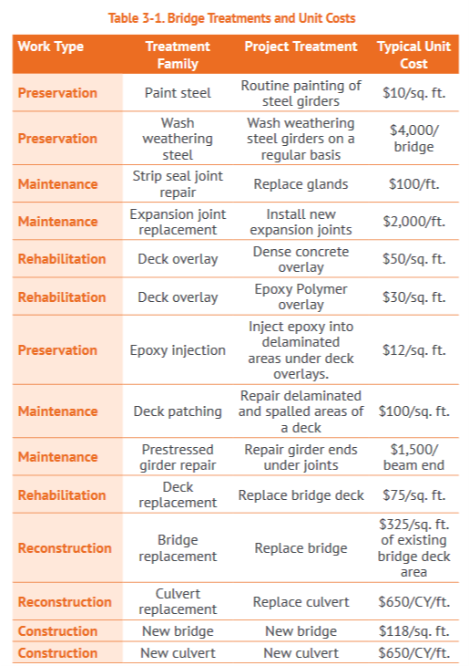

Based on the information in the table above, I was able to sort the bridge/culvert projects in the 5 Year Program into the federal work types of construction, replacement, reconstruction, maintenance or preservation.

| Location | 5 Year Program | Asset Mgmt |
| --- | --- | --- |
| I-80 INTERCHANGE | BRIDGE DECK OVERLAY | Rehabilitation |
| GRAND RIVER 1.0 MI W OF CO RD P28 | BRIDGE DECK OVERLAY | Rehabilitation |
| W FORK NODAWAY RIVER 1.6 MI E OF CO RD N51 | BRIDGE REPLACEMENT | Replacement |
| MIDDLE NODAWAY RIVER 1.8 MI S OF S JCT CO RD H20 | BRIDGE DECK OVERLAY | Rehabilitation |
| MISSISSIPPI RIVER BRIDGE IN LANSING | BRIDGE REPLACEMENT | Replacement |
| MISSISSIPPI RIVER IN LANSING | BRIDGE CLEANING | Preservation |

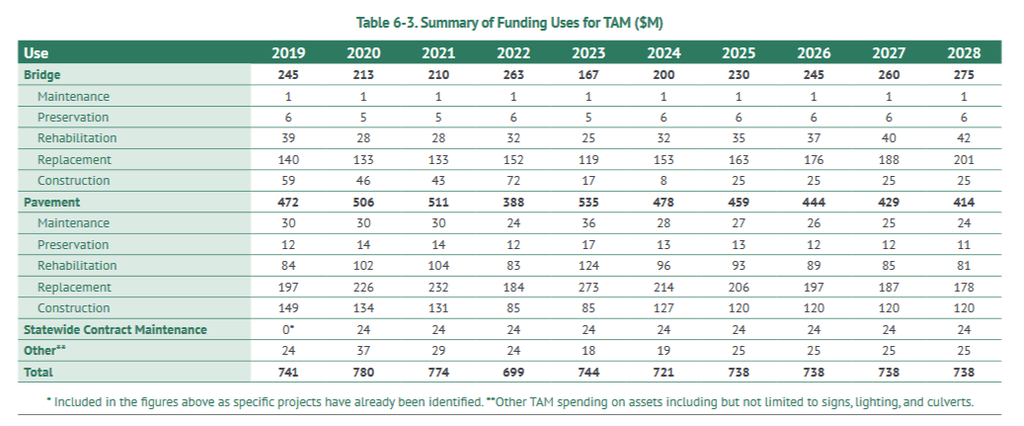

Using the information in the table above, I compared the funding levels in the 5 Year Program and asset management plan based on the federal work types. Nothing really stands outs in this comparison; the strongest relationship between the two plans appears to be between the funding levels for rehabilitation and replacement.

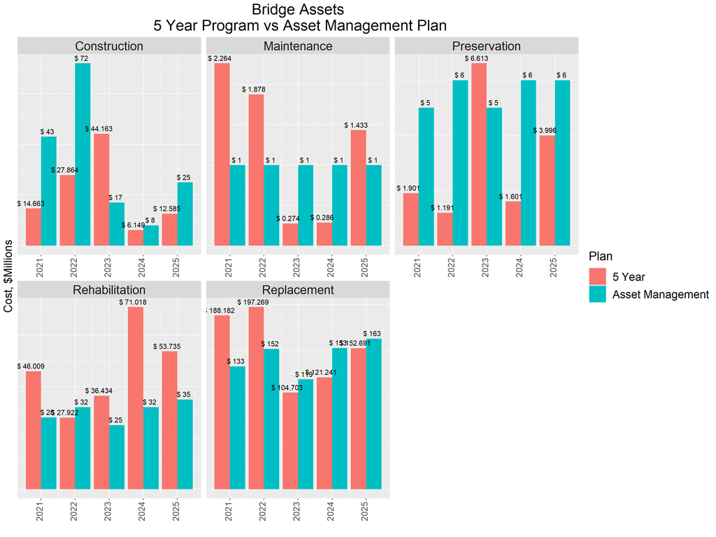

Projects/cost and funding levels can fluctuate, sometimes significantly, from year to year depending on need, so it may be hard to determine if there is any correspondence between the two plans on an annual basis by work type. Analyzing cumulative funding levels for each work type during the five year period may be a better indicator of the relationship between the two plans.

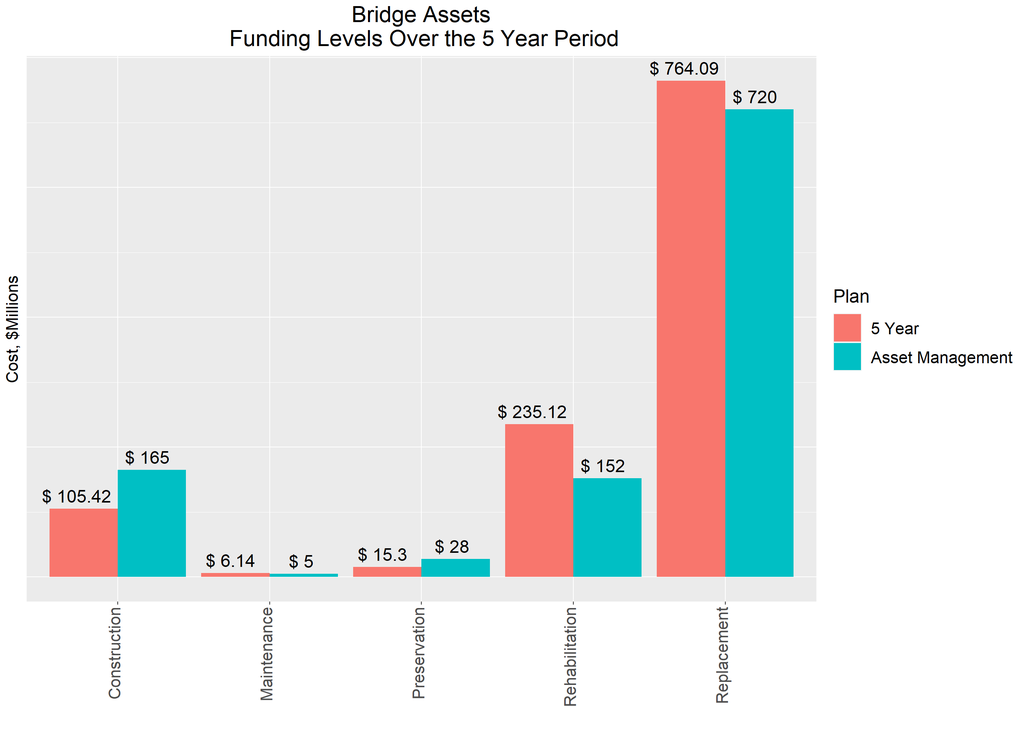

Over the five year period, the difference in total funding between the two plans is about 5.3%, for bridge assets, with slightly more funding identified in the 5 Year Program. The difference between the two plans could be due to contingency or not including items, such as landscaping, lighting or mitigation that may be a part of a project, but included in a different contract.

```
## # A tibble: 2 x 2
##   Plan             `Cost ($Billions)`
##   <chr>                         <dbl>
## 1 5 Year                         1.13
## 2 Asset Management               1.07
```

Both documents are used primarily for planning purposes and are intended to provide an estimate of funding levels which are impacted by changes due to need, priority and available funding. Analyzing the cumulative difference in funding levels over the five year period may be the best approach to defining a relationship between the plans.

Pavement Assets

Table 3-2 in the Iowa DOT’s asset management plan, shown below, provides a crosswalk between the pavement treatments, or work as described in the 5 Year Program, and the federal work types.

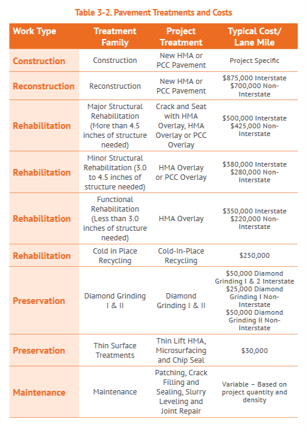

Using a process similar to the one described for the bridge asset comparison, I began to sort the pavement projects in the 5 Year Program into the federal work types. Unfortunately, the pavement work, described in the 5 Year Program, isn’t as detailed as the bridge work and I wasn’t able to categorize the pavement projects by federal work type. Consequently, I also wasn’t able to compare the funding levels by work type in the 5 Year Program with those in the asset management plan. This doesn’t mean tha the 5 Year Program is wrong or that the asset management plan doesn’t comply with federal regulation. It just mean that it work take some work to be able to determine if the pavement projects in the 5 Year Program relate to the funding levels of the pavement assets described in the asset management plan.

Just because I couldn’t sort the pavement projects in the 5 Year Program into the federal work types in the asset management plan doesn’t mean that I wasn’t able to compare annual funding levels between the two plans.

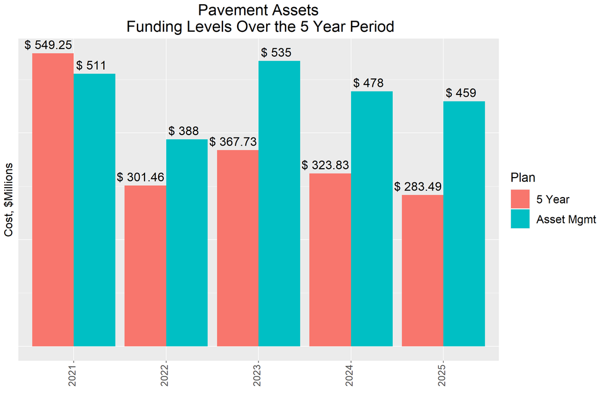

The figure above shows the funding level of the 5 Year program in 2021 is about 7% more then the documented funding level in the asset management plan. For the remaining years, 2022 - 2025, the funding level in the asset management plan is more than what is documented in the 5 Year Program; any where from 22-38% difference.

Over the five year period, there is a difference of over 20% between the two plans. This leads me to further believe there is something else going on with the pavement projects listed in the 5 Year Program that isn’t easily identified without discussions with the Iowa DOT.

```
## # A tibble: 2 x 2
##   Plan       `Cost ($Billions)`
##   <chr>                   <dbl>
## 1 5 Year                   1.83
## 2 Asset Mgmt               2.37
```

Contributions

In this project the entire team worked together and communicated throughout the project. Everyone got their work done on the agreed upon times and the quality of work was great. Lisa was the one who had the idea for the data set to look at and helped do a lot of the cleaning and helping us understand the data we were looking at. Colin as the project coordinator made sure everyone got their work done and everything was submitted on time. Everyone else had equaly contribution and everyone participated in reviewing and checking each other’s work.

Conclusion

The Iowa DOT 5 Year Program contains a wealth of information on construction projects planned between 2021-2025. Number/type of project, location, county, Iowa DOT District, route, estimated project costs and the relationship between the 5 Year Program and Asset Management plan were explored. The following conclusions were developed based on the analysis:

Conclusions developed from the analysis of the 5 Year Program describe the work type and location of projects within Iowa. The information can be used to determine project status/cost, documentation requirements, staffing resources and funding levels planned to manage bridge and pavement assets. The conclusions developed from this analysis, while only used as practice, can and most likely will be used in the work that one of our group members participates in. Being able to work on a fairly large and informative data set was interesting and with the possiblity of real world applications a unique and cool experience.